# Solution to Exercise 3.6

### 02409 Multivariate Statistics

`Week H`

```r
cars = data.frame("EngineSize" = c(3.5, 2.0, 2.4, 3.2, 3.5, 3.5, 3.2, 1.8, 1.8, 3.0, 3.0, 3.0, 3.0, 3.0, 3.0, 3.0, 2.7, 4.2, 4.2, 4.2, 4.2, 1.8, 1.8, 3.2, 3.0, 4.2, 3.0, 4.4, 2.5, 2.5, 2.5, 2.5, 3.0, 3.0, 3.0, 2.5, 3.0, 3.0, 4.4, 4.4, 4.4, 3.2, 3.2, 2.5, 3.0, 2.5, 4.2, 3.4, 3.1,
3.8, 3.8, 3.8, 3.8, 3.8, 3.8, 5.3, 4.6, 3.6, 4.6, 4.6, 4.6, 4.6, 6.0, 5.3, 5.3, 4.2, 2.5, 1.6, 1.6, 2.2, 2.2, 2.2, 3.4, 2.2, 3.5, 3.4, 3.8, 3.8, 3.5, 3.8, 4.3, 3.4, 5.7, 5.7, 5.3, 2.8, 4.3, 6.0, 5.3, 3.5, 2.4, 2.4, 2.4, 2.7, 3.5, 2.7, 3.5, 2.4,
2.4, 3.5, 2.7, 3.3, 3.8, 3.2, 3.5, 4.7, 2.0, 2.0, 2.7, 2.4, 2.4, 3.5, 2.4, 3.8, 8.3, 3.7, 3.7, 3.7, 6.8, 4.6, 4.0, 3.0, 2.0, 2.0, 2.0, 2.0, 2.0, 3.0, 3.0, 4.6, 4.6, 4.6, 3.9, 3.8, 4.6, 3.9, 4.6, 5.4, 2.3, 2.0, 3.0, 4.2, 4.8, 6.0, 4.3, 2.8, 4.8,
6.0, 4.3, 1.4, 2.0, 3.5, 2.4, 2.4, 1.7, 1.7, 1.7, 2.4, 2.4, 1.7, 2.0, 3.0, 3.0, 3.5, 3.5, 2.2, 6.0, 2.7, 1.6, 1.6, 1.6, 2.0, 2.0, 2.0, 2.7, 2.7, 3.5, 3.5, 2.7, 3.5, 3.5, 3.5, 3.5, 4.5, 4.5, 3.5, 4.5, 4.2, 3.2, 2.5, 3.0, 3.0, 4.2, 4.2, 4.2, 4.2,
4.2, 4.2, 4.2, 4.2, 4.2, 4.0, 2.4, 4.0, 3.5, 2.4, 1.6, 1.6, 1.8, 1.8, 1.8, 2.7, 3.5, 3.5, 1.6, 4.4, 4.6, 2.5, 4.7, 4.7, 3.3, 3.3, 3.0, 3.0, 3.0, 4.3, 4.3, 4.3, 3.0, 5.4, 4.6, 3.0, 3.0, 3.9, 3.9, 4.6, 4.6, 4.6, 1.6, 1.6, 2.0, 2.0, 2.3, 2.3, 3.0,
1.8, 1.8, 1.3, 1.3, 2.3, 4.0, 5.0, 5.0, 1.8, 3.2, 2.6, 2.6, 3.2, 3.2, 3.2, 3.2, 5.0, 5.5, 3.2, 5.0, 3.2, 5.0, 4.3, 5.0, 5.0, 5.5, 5.5, 2.3, 3.2, 2.6, 3.2, 5.0, 4.0, 3.0, 4.6, 4.6, 3.0, 4.6, 4.6, 4.2, 3.0, 3.8, 3.8, 2.4, 2.0, 2.0, 2.4, 2.0, 3.5,
3.8, 3.0, 3.0, 2.0, 2.4, 5.6, 3.5, 3.3, 1.8, 1.8, 2.5, 2.5, 3.5, 3.5, 3.5, 3.5, 3.5, 3.5, 3.5, 3.3, 5.6, 3.5, 2.2, 3.4, 3.4, 3.4, 2.2, 3.4, 3.8, 2.2, 3.8, 4.6, 3.4, 3.4, 5.7, 1.8, 4.5, 3.6, 3.6, 3.6, 3.6, 2.7, 3.2, 2.0, 2.0, 2.3, 2.3, 2.0, 2.0,
2.3, 2.2, 2.2, 2.2, 2.2, 2.2, 2.2, 3.0, 2.2, 1.5, 1.5, 2.5, 2.5, 2.5, 2.5, 3.0, 3.0, 2.0, 2.5, 2.5, 2.5, 2.5, 2.7, 2.5, 2.3, 2.3, 2.0, 2.0, 2.5, 2.3, 1.5, 4.7, 4.0, 3.3, 4.7, 2.4, 1.8, 1.8, 1.8, 1.5, 1.5, 1.5, 2.4, 3.0, 2.4, 3.3, 3.0, 3.0, 3.3,
3.0, 3.3, 3.3, 1.8, 1.8, 2.4, 3.4, 3.4, 1.8, 3.2, 2.0, 1.8, 1.9, 1.8, 2.8, 2.0, 1.8, 2.8, 4.0, 4.2, 6.0, 2.0, 1.8, 4.0, 2.9, 1.9, 2.5, 2.3, 2.5, 2.9, 2.5, 2.4, 2.3, 2.9, 1.9, 2.5),
                "Horsepower" = c(265, 200, 200, 270, 225, 225, 290, 170, 170, 220, 220, 220, 220, 220, 220, 220, 250, 300, 330, 340, 450, 180, 225, 250, 220, 340, 225, 325, 184, 184, 184, 184, 225, 225, 225, 184, 225, 225, 325, 325, 325, 333, 333, 184, 225, 184, 275, 185, 175,
205, 200, 240, 205, 205, 240, 295, 320, 255, 275, 300, 275, 320, 345, 295, 295, 275, 165, 103, 103, 140, 140, 140, 180, 145, 200, 180, 200, 240, 200, 200, 190, 185, 350, 350, 295, 175, 200, 300, 300, 200, 150, 150, 150, 200, 250, 200, 232, 220,
150, 255, 200, 180, 215, 215, 250, 230, 132, 132, 200, 150, 150, 232, 150, 215, 500, 210, 210, 215, 310, 232, 210, 201, 130, 110, 130, 130, 170, 155, 201, 224, 224, 239, 193, 193, 260, 280, 231, 300, 143, 130, 155, 275, 285, 325, 190, 175, 285,
300, 190,  93,  73, 240, 160, 160, 115, 117, 115, 160, 160, 127, 160, 240, 240, 240, 240, 240, 316, 173, 103, 103, 103, 138, 138, 138, 170, 170, 194, 194, 172, 260, 280, 260, 255, 340, 340, 280, 315, 275, 193, 192, 227, 235, 294, 390, 294, 294,
390, 294, 294, 390, 390, 195, 150, 190, 192, 138, 104, 104, 124, 124, 124, 170, 195, 195, 104, 282, 217, 174, 235, 235, 230, 225, 215, 215, 220, 300, 290, 300, 215, 300, 302, 232, 232, 280, 280, 239, 239, 239, 115, 163, 130, 148, 160, 160, 200,
142, 142, 197, 238, 143, 207, 292, 288, 189, 215, 168, 168, 215, 215, 215, 349, 302, 493, 215, 302, 221, 302, 275, 302, 302, 493, 493, 192, 349, 168, 221, 302, 210, 155, 224, 224, 201, 224, 302, 201, 155, 215, 215, 160, 120, 120, 160, 120, 205,
230, 210, 210, 271, 160, 305, 240, 180, 126, 126, 175, 165, 245, 265, 265, 240, 240, 287, 287, 180, 305, 245, 140, 170, 185, 185, 140, 175, 200, 140, 200, 275, 185, 185, 340, 130, 340, 315, 315, 315, 477, 228, 258, 210, 210, 220, 250, 210, 210,
250, 143, 140, 140, 140, 140, 140, 182, 140, 108, 108, 165, 165, 165, 165, 212, 212, 227, 300, 165, 165, 165, 185, 165, 155, 155, 119, 119, 155, 155, 110, 240, 245, 230, 325, 161, 130, 130, 130, 108, 108, 108, 157, 210, 157, 225, 210, 210, 225,
210, 230, 230, 180, 138, 142, 190, 190, 130, 220, 115, 180, 100, 150, 200, 115, 170, 190, 270, 335, 420, 115, 170, 270, 268, 170, 208, 247, 300, 208, 194, 197, 242, 268, 170, 208),
                "MPG_Highway" = c(23, 31, 29, 28, 24, 24, 24, 31, 30, 28, 26, 25,
                                  27, 25, 27, 25, 25, 24, 24, 20, 22, 28, 28, 29, 25, 21, 23, 22, 29, 29, 27, 27, 30, 30, 29, 28, 28, 30, 26, 26, 26, 24, 23, 28, 29, 26, 21, 26, 30, 29, 30, 28, 29, 29, 28, 18, 21, 25, 26, 26, 26, 25, 17, 18, 18, 21,
22, 34, 34, 37, 37, 37, 32, 34, 30, 32, 30, 28, 32, 28, 17, 26, 25, 25, 18, 23, 21, 17, 19, 30, 29, 29, 30, 28, 27, 29, 27, 27, 30, 27, 28, 26, 25, 25, 23, 21, 36, 36, 29, 28, 28, 27, 26, 25, 20, 22, 22, 21, 13, 19, 20, 23, 33, 36, 33, 33, 28, 27, 26, 25, 25, 25,
23, 29, 25, 24, 19, 18, 29, 33, 26, 19, 19, 17, 20, 25, 20, 18, 19, 51, 66, 22, 25, 24, 38, 44, 38, 34, 34, 37, 30, 30, 30, 25, 25, 25, 12, 26, 33, 33, 33, 34, 34, 34, 27, 27, 26, 26, 26, 26, 26, 26, 26, 23, 23, 22, 19, 20, 21, 26, 25, 26, 28, 24, 28, 28, 24, 26,
26, 23, 23, 21, 24, 19, 19, 30, 33, 32, 32, 32, 32, 27, 25, 22, 33, 16, 16, 21, 19, 17, 24, 29, 25, 24, 25, 23, 25, 23, 24, 18, 18, 26, 26, 24, 24, 25, 25, 25, 37, 34, 25, 34, 31, 32, 25, 28, 28, 25, 24, 29, 19, 14, 17, 30, 26, 25, 25, 26, 26, 27, 21, 24, 19, 26,
22, 27, 20, 26, 24, 23, 21, 19, 29, 22, 25, 27, 24, 21, 27, 25, 25, 26, 25, 23, 23, 26, 21, 19, 27, 31, 31, 30, 31, 25, 26, 28, 28, 26, 31, 19, 21, 20, 35, 35, 26, 28, 26, 28, 28, 26, 25, 26, 26, 20, 18, 25, 32, 29, 26, 26, 33, 29, 30, 33, 30, 20, 26, 24, 20, 36,
18, 26, 24, 26, 24, 29, 26, 28, 28, 29, 29, 29, 30, 29, 26, 35, 35, 35, 35, 35, 28, 34, 38, 35, 28, 28, 28, 27, 26, 26, 27, 24, 28, 28, 28, 22, 22, 31, 31, 31, 30, 27, 29, 51, 17, 21, 24, 17, 27, 40, 40, 40, 43, 39, 43, 33, 29, 33, 29, 29, 29, 29, 29, 27, 27, 33,
32, 27, 18, 17, 36, 20, 31, 31, 46, 31, 30, 30, 31, 26, 25, 22, 19, 30, 31, 25, 20, 29, 27, 28, 25, 28, 27, 28, 26, 26, 29, 27))
```

### PART 1: Test For Lower Dimension Of Model Space

Given **Theorem 3.7**, we can test for a lower dimension of model space:
$$C_{\alpha}=\left\{\left(y_{1}, \ldots, y_{n}\right) \mid
\frac{\left\|p_{M}(\mathbf{y})-p_{H}(\mathbf{y})\right\|^{2}
/(k-r)}{\left\|\mathbf{y}-p_{M}(\mathbf{y})\right\|
/(n-k)}>F\left(k-r, n-k_{1-\alpha}\right)\right\}$$

Further we have remark $3.8$

**REMARK 3.8.** Using Pythagoras’ theorem we see that there are two other ways of computing

$$\left\|p_{M}(\boldsymbol{Y})-p_{H}(\boldsymbol{Y})\right\|^{2}=\left(\mathbf{x}
\hat{\boldsymbol{\theta}}-\mathbf{x}_{0} \hat{\gamma}\right)^{\prime}
\boldsymbol{\Sigma}^{-1}\left(\mathbf{x}
\hat{\boldsymbol{\theta}}-\mathbf{x}_{0}
\hat{\gamma}\right)\text{, (3.2)}$$
besides the direct formula, namely as

$$\left\|p_{M}(\boldsymbol{Y})\right\|^{2}-\left\|p_{H}(\boldsymbol{Y})\right\|^{2}=(\mathbf{x}
\hat{\boldsymbol{\theta}})^{\prime} \boldsymbol{\Sigma}^{-1}(\mathbf{x}
\hat{\boldsymbol{\theta}})-\left(\mathbf{x}_{0}
\hat{\gamma}\right)^{\prime}
\boldsymbol{\Sigma}^{-1}\left(\mathbf{x}_{0}
\hat{\gamma}\right)\text{, (3.3)}$$
or as

$$\begin{aligned}
&\left\|\boldsymbol{Y}-p_{H}(\boldsymbol{Y})\right\|^{2}-\left\|\boldsymbol{Y}-p_{M}(\boldsymbol{Y})\right\|^{2}
\\
= &\left(\boldsymbol{Y}-\mathbf{x}_{0}
\hat{\boldsymbol{Y}}\right)^{\prime}
\boldsymbol{\Sigma}^{-1}\left(\boldsymbol{Y}-\mathbf{x}_{0}
\hat{\boldsymbol{Y}}\right)-(\boldsymbol{Y}-\mathbf{x}
\hat{\boldsymbol{\theta}})^{\prime}
\boldsymbol{\Sigma}^{-1}(\boldsymbol{Y}-\mathbf{x}
\hat{\boldsymbol{\theta}})\text{, (3.4)}
\end{aligned}$$

For numerical reasons (3.3) is normally preferred, but if one has computed the residual sum of squares using (3.4) is straight forward.

In this exercise we use the following notation:

$$\begin{aligned}
S S_{\bmod }(\operatorname{Mod})
&=\left\|p_{M}(\mathbf{Y})\right\|^{2} \\
S S_{\bmod }(H y p) &=\left\|p_{H}(\mathbf{Y})\right\|^{2} \\
S S_{r e s}(M o d) &=\left\|\mathbf{Y}-p_{M}(\mathbf{Y})\right\|^{2}
\\
S S_{r e s}(H y p) &=\left\|\mathbf{Y}-p_{H}(\mathbf{Y})\right\|^{2}
\\
D F_{\bmod }(M o d) &=k \\
D F_{\bmod }(H y p) &=r \\
D F_{r e s}(M o d) &=n-k \\
D F_{r e s}(H y p) &=n-r
\end{aligned}$$

where *SS* is the Sum of Squares, and *DF* is the Degrees of Freedom.

**1. Write the expression in Theorem 3.7, using $SS_{mod}$ in the nominator.**

**2. Write the expression in Theorem 3.7, using $SS_{res}$.**

### PART 2: Tests In GLM using RStudio

We now investigate whether the fuel efficiency for highway driving, can be determined by an intercept and the engine size and horsepower, by an intercept and the engine size, or by the engine size alone. I.e.:

$$\begin{aligned}
&M: E(Y_{ij}) = \mu + alpha \times Size_{i} + \beta \times
Power_{j}\\
&H: E(Y_{ij}) = \tau + \gamma \times Size_{i}
\end{aligned}$$

where $Size_{i}$ is the engine size, and $Power_{j}$ is the horsepower. $\mu$ and $\tau$ are intercept parameters, and $\alpha$, $\beta$, and $\gamma$ are slope parameters.

We test this bmo. a General Linear Model (GLM) in R:

```r
# Full model:
ModelM <- lm(MPG_Highway ~ EngineSize + Horsepower,data=cars)
print("Anova Type I SS:")
anova(ModelM)
print("Anova Type III SS:")
Anova(ModelM,type=3)
summary(ModelM)
```

```r
# Reduced model:
ModelH <- lm(MPG_Highway ~ EngineSize,data=cars)
print("Anova Type I SS:")
anova(ModelH)
print("Anova Type III SS:")
Anova(ModelH,type=3)
summary(ModelH)
```

The output from this code is shown in the appendix.

**3. Relate the expression in question 1 and 2 to the tables given in the R output and write the usual test statistic for *M* vs. *H*. Remember we have an intercept in our model. Confirm that both expressions derived earlier yields the same result.**

**4. How is the test statistic distributed under the nul-hypothesis and what is its P-value?**

### Appendix

#### Model M

```
## [1] "Anova Type I SS:"
```

```
## Analysis of Variance Table
##
## Response: MPG_Highway
##             Df Sum Sq Mean Sq F value    Pr(>F)
## EngineSize   1 7241.6  7241.6 467.625 < 2.2e-16 ***
## Horsepower   1  251.3   251.3  16.229 6.651e-05 ***
## Residuals  425 6581.6    15.5
## ---
## Signif. codes:  0 '***' 0.001 '**' 0.01 '*' 0.05 '.' 0.1 ' ' 1
```

```
## [1] "Anova Type III SS:"
```

```
## Anova Table (Type III tests)
##
## Response: MPG_Highway
##             Sum Sq  Df  F value    Pr(>F)
## (Intercept)  62490   1 4035.285 < 2.2e-16 ***
## EngineSize    1598   1  103.169 < 2.2e-16 ***
## Horsepower     251   1   16.229 6.651e-05 ***
## Residuals     6582 425
## ---
## Signif. codes:  0 '***' 0.001 '**' 0.01 '*' 0.05 '.' 0.1 ' ' 1
```

```
##
## Call:
## lm(formula = MPG_Highway ~ EngineSize + Horsepower, data = cars)
##
## Residuals:
##    Min     1Q Median     3Q    Max
## -9.717 -2.307 -0.371  2.269 33.293
##
## Coefficients:
##              Estimate Std. Error t value Pr(>|t|)
## (Intercept) 39.632879   0.623905  63.524  < 2e-16 ***
## EngineSize  -2.830721   0.278690 -10.157  < 2e-16 ***
## Horsepower  -0.017326   0.004301  -4.028 6.65e-05 ***
## ---
## Signif. codes:  0 '***' 0.001 '**' 0.01 '*' 0.05 '.' 0.1 ' ' 1
##
## Residual standard error: 3.935 on 425 degrees of freedom
## Multiple R-squared:  0.5324, Adjusted R-squared:  0.5302
## F-statistic: 241.9 on 2 and 425 DF,  p-value: < 2.2e-16
```

## Contour FIt Plot for MPG_Highway

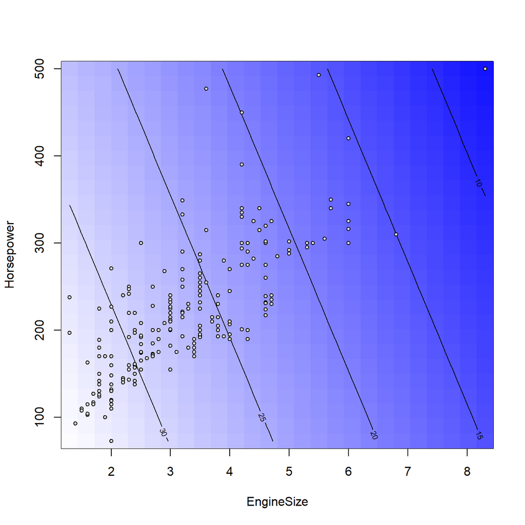

```r
# contour plot for the Full model
colblue = colorRampPalette(c("blue","white"))
contour(ModelM,~EngineSize+Horsepower,image=TRUE,img.col=colblue(100),zlim=c(5,35))
points(cars$EngineSize,cars$Horsepower,pch=21,cex=0.7,bg="lightgrey")
```

#### Model H

```
## [1] "Anova Type I SS:"
```

```
## Analysis of Variance Table
##
## Response: MPG_Highway
##             Df Sum Sq Mean Sq F value    Pr(>F)
## EngineSize   1 7241.6  7241.6  451.49 < 2.2e-16 ***
## Residuals  426 6832.9    16.0
## ---
## Signif. codes:  0 '***' 0.001 '**' 0.01 '*' 0.05 '.' 0.1 ' ' 1
```

```
## [1] "Anova Type III SS:"
```

```
## Anova Table (Type III tests)
##
## Response: MPG_Highway
##             Sum Sq  Df F value    Pr(>F)
## (Intercept)  68737   1 4285.44 < 2.2e-16 ***
## EngineSize    7242   1  451.49 < 2.2e-16 ***
## Residuals     6833 426
## ---
## Signif. codes:  0 '***' 0.001 '**' 0.01 '*' 0.05 '.' 0.1 ' ' 1
```

```
##
## Call:
## lm(formula = MPG_Highway ~ EngineSize, data = cars)
##
## Residuals:
##    Min     1Q Median     3Q    Max
## -9.889 -2.432 -0.289  2.190 34.711
##
## Coefficients:
##             Estimate Std. Error t value Pr(>|t|)
## (Intercept)  38.7186     0.5915   65.46   <2e-16 ***
## EngineSize   -3.7148     0.1748  -21.25   <2e-16 ***
## ---
## Signif. codes:  0 '***' 0.001 '**' 0.01 '*' 0.05 '.' 0.1 ' ' 1
##
## Residual standard error: 4.005 on 426 degrees of freedom
## Multiple R-squared:  0.5145, Adjusted R-squared:  0.5134
## F-statistic: 451.5 on 1 and 426 DF,  p-value: < 2.2e-16
```

```r
# intervals for 95% prediction
predictionsH = predict(ModelH,interval="prediction",level=0.95)
```

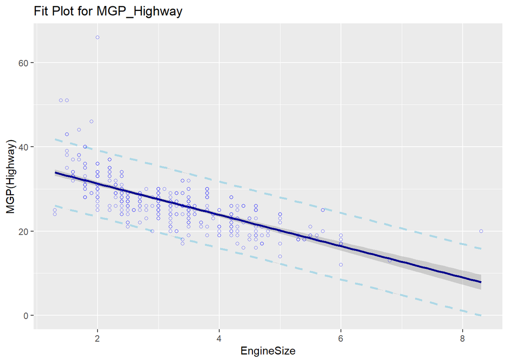

```r
ggplot(cars,aes(x=EngineSize,y=MPG_Highway))+
  geom_smooth(method='lm',formula= y ~ x,col="darkblue",lwd=0.9)+
  geom_smooth(aes(y=predictionsH[,2]),method='lm',formula= y ~ x,
              col="lightblue",linetype=2)+
  geom_smooth(aes(y=predictionsH[,3]),method='lm',formula= y ~ x,
              col="lightblue",linetype=2)+
  geom_point(color="blue",alpha=0.5,pch=1)+
  ggtitle("Fit Plot for MGP_Highway") + ylab("MGP(Highway)")
```

### SOLUTION

#### Task 1

Write the expression in Theorem 3.7, using $SS_{mod}$ in the nominator. We use remark 3.8 (3.3).

$$\begin{aligned}
&\frac{\left\|p_{M}(\mathbf{y})-p_{H}(\mathbf{y})\right\|^{2}
/(k-r)}{\left\|\mathbf{y}-p_{M}(\mathbf{y})\right\| /(n-k)}= \\
&\frac{\left[SS_{\text {mod }}(Mod)-S S_{\text {mod}}(Hyp)\right]
/\left[DF_{\text {mod}}(Mod)-DF_{\text {mod }}(Hyp)\right]}{SS_{\text
{res}}(Mod) / DF_{\text{res}}(Mod)}
\end{aligned}$$

#### Task 2

Write the expression in Theorem 3.7, using $SS_{res}$. We use remark 3.8 (3.4).

$$\begin{aligned}
&\frac{\left\|p_{M}(\mathbf{y})-p_{H}(\mathbf{y})\right\|^{2}
/(k-r)}{\left\|\mathbf{y}-p_{M}(\mathbf{y})\right\| /(n-k)}= \\
&\frac{\left[SS_{\text {res}}(Hyp)-SS_{\text {res}}(Mod)\right]
/\left[DF_{\text {res}}(Hyp)-DF_{\text {res }}(Mod)\right]}{SS_{\text
{res}}(Mod) / DF_{\text{res}}(Mod)}
\end{aligned}$$

#### Task 3

Relate the expression in question 1 and 2 to the tables given in the RStudio output and write the usual test statistic for *M* vs. *H*.

We have that:

$$\begin{aligned}
S S_{\bmod }(\operatorname{Mod}) &= 7492.96 \\
S S_{\bmod }(H y p) &= 7241.64\\
S S_{r e s}(M o d) &= 6581.56 \\
S S_{r e s}(H y p) &= 6832.87\\
D F_{\bmod }(M o d) &=2 \\
D F_{\bmod }(H y p) &=1 \\
D F_{r e s}(M o d) &=425 \\
D F_{r e s}(H y p) &=426
\end{aligned}$$

The first expression the yields:
$$\begin{aligned}
&\frac{\left[SS_{\text {mod }}(Mod)-S S_{\text {mod}}(Hyp)\right]
/\left[DF_{\text {mod}}(Mod)-DF_{\text {mod }}(Hyp)\right]}{SS_{\text
{res}}(Mod) / DF_{\text{res}}(Mod)} = \\
&\frac{[7492.96 - 7241.64]/[2 - 1]}{6581.56/425} = \\
& 16.2288
\end{aligned}$$

and the second expression:

$$\begin{aligned}
&\frac{\left[SS_{\text {res}}(Hyp)-SS_{\text {res}}(Mod)\right]
/\left[DF_{\text {res}}(Hyp)-DF_{\text {res }}(Mod)\right]}{SS_{\text
{res}}(Mod) / DF_{\text{res}}(Mod)} = \\
&\frac{[6832.87 - 6581.56]/[426 - 425]}{6581.56/425} = \\
& 16.2288
\end{aligned}$$

They are the same as expected.

#### Task 4

The test-statistic is distributed $F(k-r,n-k) = F(2-1, 425) = F(1, 425)$. We evaluate it in R:

```r
1-pf(16.2288,1,425)
```

```
## [1] 6.649883e-05
```

yielding $0.0000664988$. We therefore reject the hypothesis and choose the full model *M*.